# PRACTICAL MACHINE LEARNING - Predict Exercice Pattern/Manner

## #Background

In this project, exercise data for 6 users has been provided. One thing that people regularly do is quantify how much of a particular activity they do, but they rarely quantify how well they do it. The objective of this project is to predict the manner in which they did the exercise.

# Data Import and basic processing

The libraries required for this analysis is first loaded and the files are imported.

```r
library(caret)
library(rpart)
library(dplyr)
library(randomForest)
```

```r
library(rpart.plot)
library(RColorBrewer)
#STEP 1 - importing the files
setwd("D:/2017/Pers/Learning/Course 8 - Practical Machine Learning/Project")
pmlTrain <- read.csv("pml-training.csv", header = TRUE)
pmlTest <- read.csv("pml-testing.csv", header = TRUE)

dim(pmlTrain)
```

```
## [1] 19622   160
```

```r
dim(pmlTest)
```

```
## [1]  20 160
```

We observe that there are 160 variables in training and test data and we have to reduce the number of predictors to ensure that we are able to build the right model.

## Reducing the number of predictors

We do this in two steps First, we remove the columns which just have NAs. Then we use nearzerovariance function to remove the columns that predominantly has the same value in all the records.

```r
remNA <- colSums(is.na(pmlTrain))
table(remNA)
```

```
## remNA
##     0 19216
##    93    67
```

```r
remNA <- (colSums(is.na(pmlTrain))==0)
pmlTrainT1 <- pmlTrain[, remNA]
# using near zero variance function
NZV <- nearZeroVar(pmlTrainT1, saveMetrics = TRUE)
pmlTrainT2 <- pmlTrainT1[, !NZV$nzv]
pmlTrainT2 <- pmlTrainT2[,2:59]

dim(pmlTrainT2)
```

```
## [1] 19622    58
```

In addition to the NA and zero variance approach, we also remove the first column (X) as this is nothing but the overall counter. The preprocessing approach has helped us reduce the number of predictors to 58 from 160.

## Applying the same transformation for test data as well

```r
RemNA <- (colSums(is.na(pmlTest))==0)
pmlTestT1 <- pmlTest[, RemNA]
NZV <- nearZeroVar(pmlTestT1, saveMetrics = TRUE)
pmlTestT2 <- pmlTestT1[, !NZV$nzv]
pmlTestT2 <- pmlTestT2[, 2:59]
```

# Building predictive models

## Creating data partitions

```r
inTrain <- createDataPartition(pmlTrainT2$classe, p = 0.7, list = FALSE)
training <- pmlTrainT2[inTrain, ]
validation <- pmlTrainT2[-inTrain,]
```

## Random Forest model and applying it on Validation data set

```r
modRF1 <-train(classe~., data = training, method = "rf", trControl = trainControl(method  = "cv", 5), ntree = 250)
predRF1 <- predict(modRF1, newdata = validation)
CM1 <- confusionMatrix(validation$classe, predRF1)
CM1
```

```
## Confusion Matrix and Statistics
##
##           Reference
## Prediction    A    B    C    D    E
##          A 1674    0    0    0    0
##          B    0 1139    0    0    0
##          C    0    0 1026    0    0
##          D    0    0    0  964    0
##          E    0    0    0    0 1082
##
## Overall Statistics
##
##                Accuracy : 1
##                  95% CI : (0.9994, 1)
##     No Information Rate : 0.2845
##     P-Value [Acc > NIR] : < 2.2e-16
##
##                   Kappa : 1
##  Mcnemar's Test P-Value : NA
##
## Statistics by Class:
##
##                      Class: A Class: B Class: C Class: D Class: E
## Sensitivity            1.0000   1.0000   1.0000   1.0000   1.0000
## Specificity            1.0000   1.0000   1.0000   1.0000   1.0000
## Pos Pred Value         1.0000   1.0000   1.0000   1.0000   1.0000
## Neg Pred Value         1.0000   1.0000   1.0000   1.0000   1.0000
## Prevalence             0.2845   0.1935   0.1743   0.1638   0.1839
## Detection Rate         0.2845   0.1935   0.1743   0.1638   0.1839
## Detection Prevalence   0.2845   0.1935   0.1743   0.1638   0.1839
## Balanced Accuracy      1.0000   1.0000   1.0000   1.0000   1.0000
```

## Decision Tree

```r
modDT <- rpart(classe~., data = training, method = "class")
predDT <- predict(modDT, validation, type = "class")
CM2 <- confusionMatrix(predDT, validation$classe)
CM2
```

```
## Confusion Matrix and Statistics
##
##           Reference
## Prediction    A    B    C    D    E
##          A 1608   49    7    2    0
##          B   48  939   67   58    0
##          C   18  144  933  142   46
##          D    0    7    9  598   63
##          E    0    0   10  164  973
##
## Overall Statistics
##
##                Accuracy : 0.8583
##                  95% CI : (0.8491, 0.8671)
##     No Information Rate : 0.2845
##     P-Value [Acc > NIR] : < 2.2e-16
##
##                   Kappa : 0.8207
##  Mcnemar's Test P-Value : NA
##
## Statistics by Class:
##
##                      Class: A Class: B Class: C Class: D Class: E
## Sensitivity            0.9606   0.8244   0.9094   0.6203   0.8993
## Specificity            0.9862   0.9635   0.9280   0.9839   0.9638
## Pos Pred Value         0.9652   0.8444   0.7272   0.8833   0.8483
## Neg Pred Value         0.9844   0.9581   0.9798   0.9297   0.9770
## Prevalence             0.2845   0.1935   0.1743   0.1638   0.1839
## Detection Rate         0.2732   0.1596   0.1585   0.1016   0.1653
## Detection Prevalence   0.2831   0.1890   0.2180   0.1150   0.1949
## Balanced Accuracy      0.9734   0.8940   0.9187   0.8021   0.9315
```

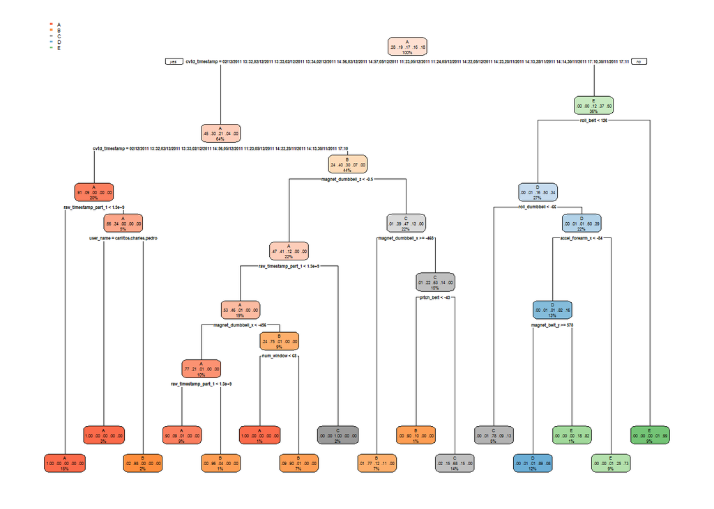

```r
rpart.plot(modDT)
```

## Applying the model on testing data

```r
predictTest <- predict(modRF1, pmlTestT2)
predictTest
```

```
##  [1] B A B A A E D B A A B C B A E E A B B B
## Levels: A B C D E
```